# Lab 3: CNNs and Deep Learning

## TBMI26/732A55 Neural Networks and Learning Systems

## 2D Convolution

For the further steps, we often need to visualize an image and we define a shortcut for that:

```python
from matplotlib import pyplot as plt
%matplotlib inline
import numpy as np
import scipy.signal as signal
from scipy.linalg import toeplitz
import cv2
import tensorflow as tf


def visualize(img):
    plt.imshow(img,'gray')
    plt.colorbar()
    plt.show()
    print('Image size:', img.shape)
```

Convolution can be performed in 2D using the function `scipy.signal.convolve2d()`.

**Task 1:** Use this function to generate a 2D kernel of size $33\times33$ by five times cascading 2D convolutions of $h$ with itself, starting with $h = \begin{array}{|c|c|} \hline \frac{1}{4} & \frac{1}{4} \\ \hline \frac{1}{4} & \frac{1}{4} \\ \hline \end{array}$. Visualize the kernel.

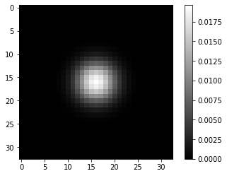

```
Image size: (33, 33)
```

```python
h = np.array([[1/4, 1/4], [1/4, 1/4]])

for i in range(0, 5):
    h = signal.convolve2d(h, h)

visualize(h)
```

**Task 2:** Now, load the image 'MR15^044.JPG' (a sample from ImageNet), convert it to gray-scale by summing its R-, G-, and B-values at each pixel, and normalize it to the interval $[0;1]$. Convolve it with $h$ from the previous task with the options `'valid'` and `'same'`. Visualize all three images. What differences do you observe regarding the size and intensity of the output?

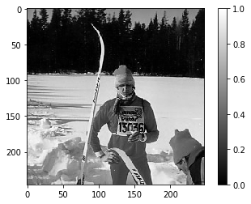

```
Image size: (246, 248)
```

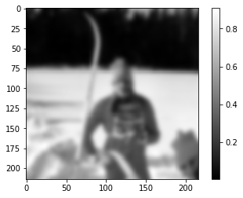

```
Image size: (214, 216)
```

```
Image size: (246, 248)
```

```python
img = plt.imread("MR15^044.JPG")
#Make img black and white
img = np.sum(img, 2)
#Normalize
img -= np.min(img)
img = img/np.max(img)

img_con_val = signal.convolve2d(img, h, mode="valid")
img_con_same = signal.convolve2d(img, h, mode="same")

visualize(img)
visualize(img_con_val)
visualize(img_con_same)
```

More information about this: https://docs.scipy.org/doc/scipy/reference/generated/scipy.signal.convolve2d.html

Strided convolution removes samples. According to the Nyquist theorem, this can generate aliasing artifacts.

**Task 3:** Visualize the original gray-scale image and the output image from the previous task (with option `'same'`) with only keping every fifth row and column (stride 5). What do you observe, in particular at the ski?

```
Image size: (50, 50)
```

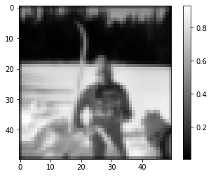

```
Image size: (50, 50)
```

```python
visualize(img[::5,::5])
visualize(img_con_same[::5,::5])
```

**Answer:** We can now see that the image is "missing" details, it's much more shoppy and therefore have less details. However, I would say that it is easier to see the last one which has had the kernel rather than the first one. Note that having great resolution and detail is not always the best way, we use a convolution to make the picture hopefully smaller and enhance the abstact features such as line and contrast.

## Convolution in TensorFlow

We will now repeat the same steps in TensorFlow, where we will exploit its capability to perform *eager execution*. This is initialized as follows:

```python
print('TensorFlow version '+tf.__version__)
tf.enable_eager_execution()
if tf.executing_eagerly():
    print('Eager execution activated!')
```

```
TensorFlow version 1.14.0
Eager execution activated!
```

TensorFlow allows to map from and to numpy. Also, operations are automatically casted. In order to get used to TensorFlow and the casting, we repeat the convolution 1.a) from class 5 (see Lisam). As you have learned in the lecture, any convolution with kernel $h$ can also be performed as matrix multiplication by the Toeplitz matrix $H$.

**Task 4:** Use `scipy.linalg.toeplitz` to generate the matrix $H$ for the kernel $h= \begin{array}{|c|c|c|} \hline \hphantom{-}1 & \hphantom{-}\textbf{2} & -2 \\ \hline \end{array}$ and boundary condition `'same'` and $f= \begin{array}{|c|c|c|c|c|c|c|c|} \hline \hphantom{-}1 & -1 & -2 & \hphantom{-}\textbf{0} & -1 & \hphantom{-}1 & \hphantom{-}2 & -1 \\ \hline \end{array}$ in TensorFlow (`tf.constant()`). Multiply $H$ and $f$ and display the result. Verify that the result is the same as in 1.a). What are the respective classes of $H$, $f$, and the result?  
Hints: `scipy.linalg.toeplitz` can take the first column and row as input; `[*np.zeros()]=np.zeros()` (`*` dereferences all elements of a tuple)

```python
f = tf.transpose(np.atleast_2d(tf.constant([1, -1, -2, 0, -1, 1, 2, -1])))
H = toeplitz([2, -2, 0, 0, 0, 0, 0, 0], [2, 1, 0, 0, 0, 0, 0, 0])
res = tf.matmul(H, f)
print(res)
```

```
tf.Tensor(
[[ 1]
 [-6]
 [-2]
 [ 3]
 [-1]
 [ 6]
 [ 1]
 [-6]], shape=(8, 1), dtype=int32)
```

Keras layers can be applied in eager mode using the `tf.keras.layers` package. **NOTE:** `tf.keras.layers` and **NOT** `keras.layers`.

**Task 5:** Perform the convolution from the previous task using a convolution layer `Conv1D` and a (trivial) `Sequential` model from `tf.keras`.  
Hints: RTFM of `tf.keras.Sequential` - weights can be set for the model (list) or the layer (by traversing the layers list). Apply `use_bias=False` to avoid random DC-shifts.

```python
f = np.asarray([0, 1, -1, -2, 0, -1, 1, 2, -1, 0])
h = np.asarray([1, 2, -2])

model = tf.keras.models.Sequential()
model.add(tf.keras.layers.Conv1D(1, 3, use_bias = False, padding = "same", input_shape = (10, 1)))
model.layers[0].set_weights(np.asarray([[[[i]] for i in h[::-1]]]))
res = model.predict(np.asarray([np.ndarray.transpose(np.asarray([f]))]))
print(res)
```

```
[[[ 1.]
  [ 1.]
  [-6.]
  [-2.]
  [ 3.]
  [-1.]
  [ 6.]
  [ 1.]
  [-6.]
  [ 2.]]]
```

**Task 6:** Apply the cascaded $33\times33$ filter from task 1 to the image from task 2 using a `Conv2D` layer. Compare the result visually and by subtracting the fitting result from task 2.

```
Image size: (246, 248)
```

```
Image size: (246, 248)
```

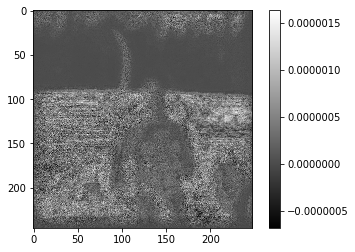

```
Image size: (246, 248)
The difference is:
0.013957687226471786
```

```python
h = np.array([[1/4, 1/4], [1/4, 1/4]])
for i in range(0, 5):
    h = signal.convolve2d(h, h)
tmp = img.reshape(img.shape[0], img.shape[1], 1)

model = tf.keras.models.Sequential()
model.add(tf.keras.layers.Conv2D(1, 33, use_bias = False, input_shape = tmp.shape, padding = "same"))
model.set_weights([h.reshape(h.shape[0], h.shape[1], 1, 1)])
tmp_img = np.array(tmp, dtype = "float32").reshape(1, tmp.shape[0], tmp.shape[1], 1)
res = model(tmp_img).numpy().squeeze()
visualize(res)
visualize(img_con_same)
diff = img_con_same - res
visualize(diff)
print("The difference is: ")
print(np.sum(diff))
```

**Answer:** We can clearly see that the pictures are very similar and if you would have asked us, by just looking at the first two picture, we would say that they are the same. However, we can see that they have very small differences at the last picture as well as the value.

**Task 7:** Repeat the previous task with stride 5 and compare the result visually and by subtracting the fitting result from task 3. Repeat the task, but with a $1\times1$ filter (coefficient `1`) and stride 5. Compare again the result visually and by subtracting the fitting result from task 3.  
Hint: You might need to adjust the offset for the subsampling.

```
Image size: (50, 50)
```

```
Image size: (50, 50)
```

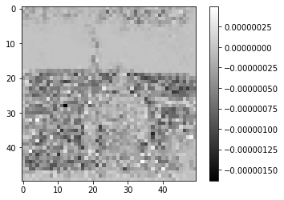

```
Image size: (50, 50)
The difference is:
0.0005729072363539495
```

```
Image size: (50, 50)
```

```
Image size: (50, 50)
```

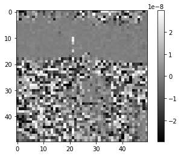

```
Image size: (50, 50)
1.1219893743599774e-06
```

```python
model = tf.keras.models.Sequential()
model.add(tf.keras.layers.Conv2D(1,
                                 33,
                                 strides = (5, 5),
                                 use_bias = False,
                                 padding = "same",
                                 input_shape = (img.shape[0],
                                                img.shape[1],
                                                1)))
model.layers[0].set_weights(np.asarray([h.reshape(33, 33, 1, 1)]))

pred = model.predict(np.asarray([img.reshape(246, 248, 1)]))
visualize(pred[0].reshape(50, 50))

tmp = img_con_same[::5, 1::5]
visualize(tmp)
diff = pred[0].reshape(50, 50) - tmp
visualize(diff)
print("The difference is: ")
print(np.abs(np.sum(diff)))


model = tf.keras.models.Sequential()
model.add(tf.keras.layers.Conv2D(1,
                                 1,
                                 strides = 5,
                                 use_bias = False,
                                 padding = "same",
                                 input_shape = (img.shape[0],
                                                img.shape[1],
                                                1)))
model.layers[0].set_weights(np.asarray([[[[[1]]]]]))
pred = model.predict(np.asarray([img.reshape(246, 248, 1)]))

visualize(pred[0].reshape(50, 50))
visualize(img[::5, ::5])
diff = pred[0].reshape(50, 50) - img[::5, ::5]
visualize(diff)
print(np.abs(np.sum(diff)))
```

We now define a new filter that is, unlike $h$, anti-symmetric:

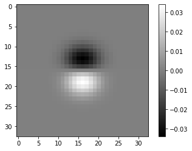

```
Image size: (33, 33)
```

```python
fsz = 33
hfsz = 17
g = h*(np.expand_dims(np.arange(-hfsz+1,hfsz),1)@np.ones((1,fsz)))
visualize(g)
```

**Task 8:** repeat tasks 6 & 7 with $g$ instead of $h$. What difference do you observe and why?

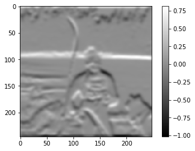

```
Image size: (246, 248)
```

```
Image size: (246, 248)
```

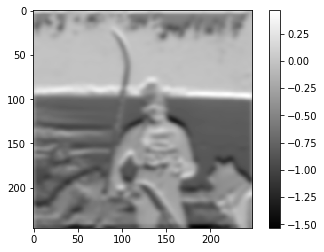

```
Image size: (246, 248)
The difference is:
25562.027501130466
```

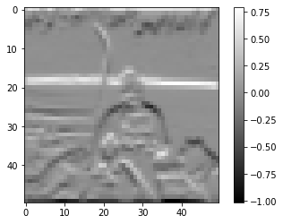

```
Image size: (50, 50)
```

```
Image size: (50, 50)
```

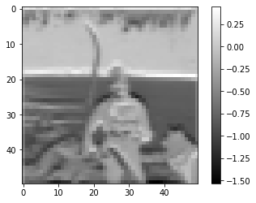

```
Image size: (50, 50)
The difference is:
1039.2931902720275
```

```python
model = tf.keras.models.Sequential()
model.add(tf.keras.layers.Conv2D(1, 33, use_bias = False, padding = "same", input_shape = (img.shape[0], img.shape[1], 1)))
model.layers[0].set_weights(np.asarray([g.reshape(33, 33, 1, 1)]))
pred = model.predict(np.asarray([img.reshape(246, 248, 1)]))

visualize(pred[0].reshape(246, 248))
visualize(img_con_same)
diff = pred[0].reshape(246, 248) - img_con_same
visualize(diff)
print("The difference is: ")
print(np.abs(np.sum(diff)))


model = tf.keras.models.Sequential()
model.add(tf.keras.layers.Conv2D(1,
                                 33,
                                 strides = (5, 5),
                                 use_bias = False,
                                 padding = "same",
                                 input_shape = (img.shape[0],
                                                img.shape[1],
                                                1)))

model.layers[0].set_weights(np.asarray([g.reshape(33, 33, 1, 1)]))
pred = model.predict(np.asarray([img.reshape(246, 248, 1)]))

visualize(pred[0].reshape(50, 50))
tmp = img_con_same[::5, 1::5]
visualize(tmp)
diff = pred[0].reshape(50, 50) - tmp
visualize(diff)
print("The difference is: ")
print(np.abs(np.sum(diff)))
```

**Answer:** We can now see that the last image (of each set of three) that represents the difference is much more clear than the others that we have done earlier. That's the reason why the difference value also is much higher.

## Training layers

We now take the input and output from task 6 as training data (input and output) for supervised learning of a convolution layer.  
**Task 9:** Although we only have a single input and output image, we can expect the training to work, although this usually requires multiple samples. Why? Define two tensors `batch` and `label` that contain the data from task 6.

**Answer:** It will work since the model will learn the kernel when we iterate the image.

```python
batch = tmp_img
label = img_con_same.reshape(1, 246, 248, 1)
```

**Task 10:** We want to apply the L1-loss. Define a suitable function `loss(model, x, y)` that can be used during training.

```python
def loss(model, x, y):
    tmp = tf.abs(tf.reduce_mean(model(x)-y))
    return(tmp)
```

```python
def loss(model, x, y):
    error = y - model(x)
    return tf.reduce_mean(tf.abs(error))
```

Training a layers requires computing the gradient. For TF in eager mode, we use `GradientTape()` for this purpose.  
**Task 11:** Train the model from task 6 (but without assigning the weights) using the data from task 9, the loss from task 10, and `GradientDescentOptimizer()`. During training, print the loss every 100 steps and visualize the learned kernel after training.  
Hint: add a kernel_constraint to be non-negative.

```
Iteration 100 with loss: 0.09433019161224365
Iteration 200 with loss: 0.037018973380327225
Iteration 300 with loss: 0.04733109474182129
Iteration 400 with loss: 0.056057609617710114
Iteration 500 with loss: 0.055167898535728455
Iteration 600 with loss: 0.053881142288446426
Iteration 700 with loss: 0.05332611873745918
Iteration 800 with loss: 0.05285593867301941
Iteration 900 with loss: 0.05232740938663483
Iteration 1000 with loss: 0.051817264407873154
Iteration 1100 with loss: 0.051207710057497025
Iteration 1200 with loss: 0.0505959689617157
Iteration 1300 with loss: 0.05013040825724602
Iteration 1400 with loss: 0.0499110147356987
Iteration 1500 with loss: 0.049838390201330185
Iteration 1600 with loss: 0.04990758001804352
Iteration 1700 with loss: 0.04996068775653839
Iteration 1800 with loss: 0.04994037002325058
Iteration 1900 with loss: 0.049955569207668304
Iteration 2000 with loss: 0.05001485347747803
Iteration 2100 with loss: 0.050059735774993896
Iteration 2200 with loss: 0.05006646737456322
Iteration 2300 with loss: 0.050104156136512756
Iteration 2400 with loss: 0.050158075988292694
Iteration 2500 with loss: 0.05017562955617905
Iteration 2600 with loss: 0.05016613006591797
Iteration 2700 with loss: 0.05017709732055664
Iteration 2800 with loss: 0.05019242689013481
Iteration 2900 with loss: 0.050216950476169586
Iteration 3000 with loss: 0.050223179161548615
Iteration 3100 with loss: 0.05021172761917114
Iteration 3200 with loss: 0.05016692727804184
Iteration 3300 with loss: 0.05009668320417404
Iteration 3400 with loss: 0.05004275217652321
Iteration 3500 with loss: 0.04999319463968277
Iteration 3600 with loss: 0.04998401552438736
Iteration 3700 with loss: 0.05000433698296547
Iteration 3800 with loss: 0.050040047615766525
Iteration 3900 with loss: 0.050064340233802795
Iteration 4000 with loss: 0.050070516765117645
Iteration 4100 with loss: 0.05010995641350746
Iteration 4200 with loss: 0.050128985196352005
Iteration 4300 with loss: 0.050167396664619446
Iteration 4400 with loss: 0.050204548984766006
Iteration 4500 with loss: 0.05022962763905525
Iteration 4600 with loss: 0.050242867320775986
Iteration 4700 with loss: 0.05023496598005295
Iteration 4800 with loss: 0.05021639168262482
Iteration 4900 with loss: 0.05017898976802826
```

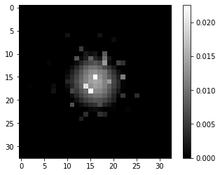

```
Image size: (33, 33)
```

```python
model = tf.keras.models.Sequential()
model.add(tf.keras.layers.Conv2D(1,
                          33,
                          use_bias = False,
                          kernel_constraint = tf.keras.constraints.NonNeg(),
                          padding = "same",
                          input_shape = (img.shape[0], img.shape[1], 1)))

optimizer = tf.train.GradientDescentOptimizer(learning_rate = 0.001)

for i in range(5000):

    with tf.GradientTape() as tp:
        l = loss(model, batch, label)
        grad = tp.gradient(l, model.variables)
        optimizer.apply_gradients(zip(grad, model.variables))

        if i%100==0 and i>0:
            print("Iteration {} with loss: {}".format(i, l))

visualize(np.asarray(model.layers[0].get_weights()[0]).reshape(33, 33))
```

The result can be improved in several ways: data augmentation (e.g. by flipping the image, using the three RGB-channel separately), regularizing the weights (e.g. using the L1-norm), and replacing the optimizer (e.g., ADAM).  
**Extra task (not to be done before task 14 is completed):** Try to improve the result using one or several of the mentioned approaches.

## Training a whole network

So far, we have been training a single layer and we have been following the progress with the help of the Eager mode. If we want to train a whole network, it is much better to leave the Eager mode and to compile the graph. For this, we need to kill the notebook kernel ("Kernel" -> "Restart"). After that, we continue below in the classical TensorFlow mode.

```python
import tensorflow as tf
print('TensorFlow version '+tf.__version__)
import matplotlib.pyplot as plt
%matplotlib inline
import numpy as np
from keras.datasets import cifar10
from keras.utils import to_categorical
```

```
TensorFlow version 1.14.0
```

**Task 12:** We will train on CIFAR10, which is contained in `keras.datasets`. Download the dataset, show a sample for each class, convert the labels to one-hot coding, and normalize the images.

[figure not shown]

```
Image size: (32, 32, 3)
```

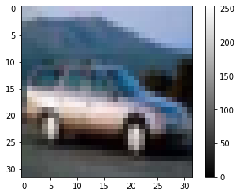

```
Image size: (32, 32, 3)
```

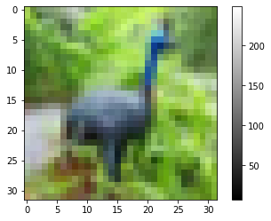

```
Image size: (32, 32, 3)
```

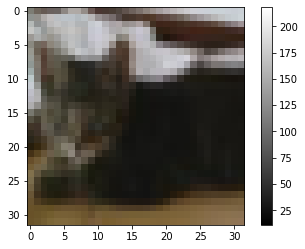

```
Image size: (32, 32, 3)
```

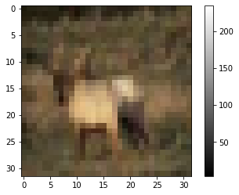

```
Image size: (32, 32, 3)
```

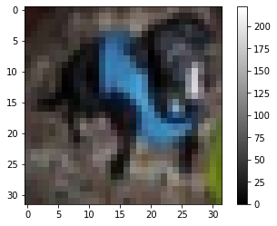

```
Image size: (32, 32, 3)
```

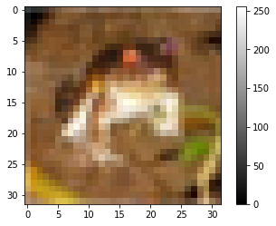

```
Image size: (32, 32, 3)
```

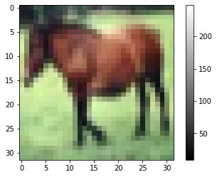

```
Image size: (32, 32, 3)
```

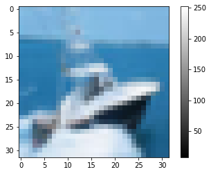

```
Image size: (32, 32, 3)
```

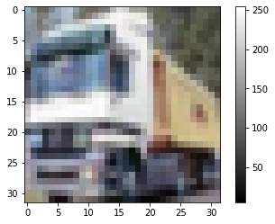

```
Image size: (32, 32, 3)
```

```python
(xTrain, yTrain), (xTest, yTest) = tf.keras.datasets.cifar10.load_data()
#print(np.unique(yTrain))
for i in range(10):
    for x, y in zip(xTrain, yTrain):
        if y[0] ==i:
            visualize(x)
            break

yTest = to_categorical(yTest, 10)
yTrain = to_categorical(yTrain, 10)
xTrain = xTrain-np.min(xTrain)
xTrain = xTrain/np.max(xTrain)
xTest = xTest-np.min(xTest)
xTest = xTest/np.max(xTest)
```

**Task 13:** Build the depicted LeNet5-inspired model using Keras standard components.

[figure not shown]

```python
from keras.models import Sequential
from keras.layers import Activation, Dense, Dropout, Flatten
from keras.layers.convolutional import Conv2D, MaxPooling2D
from keras.layers.normalization import BatchNormalization
from keras.optimizers import Adam
tf.compat.v1.disable_eager_execution()

def letnet5():
    model = Sequential()

    model.add(Conv2D(32, (3, 3), padding = "same", input_shape = (32, 32, 3)))
    model.add(Activation("elu"))
    model.add(BatchNormalization())

    model.add(Conv2D(32, (3, 3), padding = "same"))
    model.add(Activation("elu"))
    model.add(BatchNormalization())
    model.add(MaxPooling2D(pool_size = (2, 2)))
    model.add(Dropout(0.2))

    model.add(Conv2D(64, (3, 3), padding = "same"))
    model.add(Activation("elu"))
    model.add(BatchNormalization())

    model.add(Conv2D(64, (3, 3), padding = "same"))
    model.add(Activation("elu"))
    model.add(BatchNormalization())
    model.add(MaxPooling2D(pool_size = (2, 2)))
    model.add(Dropout(0.3))

    model.add(Conv2D(128, (3, 3), padding = "same"))
    model.add(Activation("elu"))
    model.add(BatchNormalization())

    model.add(Conv2D(128, (3, 3), padding = "same"))
    model.add(Activation("elu"))
    model.add(BatchNormalization())
    model.add(MaxPooling2D(pool_size = (2, 2)))
    model.add(Dropout(0.4))

    model.add(Flatten())
    model.add(Dense(10, activation = "softmax"))

    tmp = Adam(lr = 0.001, decay = 1e-6)
    model.compile(loss = "categorical_crossentropy", optimizer = tmp, metrics = ["accuracy"])
    return model
```

We will now train the network. For displaying the performance we define a helper function:

```python
def plot_model_history(model):
    line_w = 3
    fig_size = (8, 6)
    plt.figure(0)
    plt.plot(model.history['acc'],'r', lw=line_w)
    plt.plot(model.history['val_acc'],'b', lw=line_w)
    plt.rcParams['figure.figsize'] = fig_size
    plt.xlabel("Epoch number")
    plt.ylabel("Accuracy")
    plt.title("Training Accuracy vs Validation Accuracy")
    plt.legend(['Training','Validation'])
    plt.grid(True)
```

**Task 14:** Train the defined model for 50 epochs and a suitable batch size and display the result.

[output not shown]

```
Train on 50000 samples, validate on 10000 samples
```

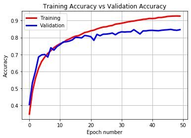

```python
model = letnet5()
fitted = model.fit(xTrain, yTrain, validation_data = (xTest, yTest), batch_size = 1000, epochs = 50)
plot_model_history(fitted)
```

The results can be improved in several ways, e.g., by successively reducing the learning rate (divided by two after 30 and 40 epochs), by data augmentation (`ImageDataGenerator`), and by weight regularization (see above).  
**Extra task:** Try to improve the result using one or several of the mentioned approaches.  
Hint: you need to define a suitable callback function to change the learning rate during training.